# 3057878_CSCU9M3_TheAssignment_Aut22

## Executive Summary

The following report contains a sentiment analysis of 20 text files that each contain a full-length sci-fi book.. Based on the three act-structure: beginning, middle, and end; each book was split into three and was analyzed. A table was then procured to neatly produce a visual dataframe of each act's analysis and the entire book's analysis. Discoveries concluded that the books followed a three-act structure that laid out a positive approach to the readers in the introduction, raised the stakes as negativity grew in the second act, and concluded the book either with a good or bad ending. In regards to their rankings, readers preferred a positive story as it took the first five spots with most of the other stories falling into the negatives. Finally, Frankenstein by Mary Shelley was regarded as the story that had both the largest positive and negative factor as it catered more as a cautionary tale rather than a direct stab of a possible future. Suggestions looked more into how the dataset can be more varied by comparing it to male authors, how a word analysis can be used to correlate to human society, and how writing styles can affect one’s ranking.

## Introduction

- What parts of these books hold the most significant sentiment? Does it follow the traditional three-act structure?
- How do the endings affect their rankings? Does a bad ending mean a lower ranking?
- Which book has the largest negative factor? Why do you think so? Which book has the largest positive factor? Why do you think so?

Since the sci-fi genre is known for being gritty and gritty and dark, negative results are expected.

## Data Cleaning

Since the text files contain Project Gutenberg's licensing details, table of contents, and some of the author's other works, these must be discarded to be able to accurately interpret the data. The following imported libraries were used to perform such tasks

```python
import nltk
from nltk.sentiment.vader import SentimentIntensityAnalyzer
analyser = SentimentIntensityAnalyzer()

import pandas as pd
```

Each book was first split into paragraphs, then enumerated to be able to identify the index of each paragraph [7]. This is done since each book differs in where the story actually starts to where it ends. The unneeded portions/paragraphs were then discarded.

```python
# Frankenstein, by Mary Wollstonecraft (Godwin) Shelley
with open('Gutenberg_books/84-0.txt','r+',encoding = "utf8", errors = "ignore") as fid:
    FRANK = fid.read()
    frankPar = FRANK.split('\n\n')
    frankPar = [i.replace('\n',' ') for i in frankPar]
    del frankPar[0:16]
    del frankPar[825:878]
    #for i, l in enumerate(frankPar):
    #    print(i,l)
```

After removal, the paragraph list is then joined to be able to tokenize them as sentences.

```python
frankenstein = ''.join(frankPar)
frankenstein_sentences = nltk.sent_tokenize(''.join(frankenstein))
```

Each book is then split into three parts to count for the "three-act-structure". This is done through the intervals function which takes the number of sentencecs in the book and divides them into three.

```python
# This function will split the text into three "acts" [2]
def intervals(parts, sentences):
    acts = sentences / parts
    return [(i * acts, (i + 1) * acts) for i in range(parts)]
```

```python
print(intervals(3,len(frankenstein_sentences)))
```

```
[(0.0, 865.6666666666666), (865.6666666666666, 1731.3333333333333), (1731.3333333333333, 2597.0)]
```

Each part was then identified and processed through a sentiment analyser. And another test was conducted to analyze the entire book.

```python
frankenstein_1score = analyser.polarity_scores(' '.join(frankenstein_sentences[0:867]))
frankenstein_2score = analyser.polarity_scores(' '.join(frankenstein_sentences[867:1732]))
frankenstein_3score = analyser.polarity_scores(' '.join(frankenstein_sentences[1732:2598]))
frankenstein_4score = analyser.polarity_scores(' '.join(frankenstein_sentences[0:2598]))
display(frankenstein_1score)
display(frankenstein_2score)
display(frankenstein_3score)
display(frankenstein_4score)
```

```
{'neg': 0.115, 'neu': 0.709, 'pos': 0.175, 'compound': 1.0}
```

```
{'neg': 0.133, 'neu': 0.7, 'pos': 0.167, 'compound': 1.0}
```

```
{'neg': 0.159, 'neu': 0.697, 'pos': 0.144, 'compound': -0.9999}
```

```
{'neg': 0.138, 'neu': 0.702, 'pos': 0.16, 'compound': 1.0}
```

The following cells cover the next 19 books.

```python
# Anthem, by Ayn Rand
with open('Gutenberg_books/1250-0.txt','r+',encoding = "utf8", errors = "ignore") as fid:
    anthem = fid.read()
    antPar = anthem.split('\n\n')
    antPar = [i.replace('\n',' ') for i in antPar]
    del antPar[0:26]
    del antPar[394:449]
    #for i, l in enumerate(antPar):
    #    print(i,l)
anthem = ''.join(antPar)
anthem_sentences = nltk.sent_tokenize(''.join(anthem))
# print(intervals(3,len(anthem_sentences)))
anthem_1score = analyser.polarity_scores(' '.join(anthem_sentences[0:389]))
anthem_2score = analyser.polarity_scores(' '.join(anthem_sentences[389:776]))
anthem_3score = analyser.polarity_scores(' '.join(anthem_sentences[776:1164]))
anthem_4score = analyser.polarity_scores(' '.join(anthem_sentences[0:1164]))
```

```python
# All Cats Are Gray, by Andre Alice Norton
with open('Gutenberg_books/29019-0.txt','r+',encoding = "utf8", errors = "ignore") as fid:
    cats = fid.read()
    catsPar = cats.split('\n\n')
    catsPar = [i.replace('\n',' ') for i in catsPar]
    del catsPar[0:16]
    del catsPar[52:109]
    #for i, l in enumerate(catsPar):
     #   print(i,l)
    allcats = ' '.join(catsPar)
allcats_sentences = nltk.sent_tokenize(''.join(allcats))
# print(intervals(3,len(allcats_sentences)))
allcats_1score = analyser.polarity_scores(' '.join(allcats_sentences[0:63]))
allcats_2score = analyser.polarity_scores(' '.join(allcats_sentences[63:126]))
allcats_3score = analyser.polarity_scores(' '.join(allcats_sentences[126:189]))
allcats_4score = analyser.polarity_scores(' '.join(allcats_sentences[0:189]))
```

```python
# Plague Ship, by Andre Norton
with open('Gutenberg_books/pg16921.txt','r+',encoding = "utf8", errors = "ignore") as fid:
    ship = fid.read()
    shipPar = ship.split('\n\n')
    shipPar = [i.replace('\n',' ') for i in shipPar]
    del shipPar[0:18]
    del shipPar[1366:1426]
    #for i, l in enumerate(shipPar):
    #    print(i,l)
plagueship = ''.join(shipPar)
plagueship_sentences = nltk.sent_tokenize(''.join(plagueship))
# print(intervals(3,len(plagueship_sentences)))
plagueship_1score = analyser.polarity_scores(' '.join(plagueship_sentences[0:1070]))
plagueship_2score = analyser.polarity_scores(' '.join(plagueship_sentences[1070:2143]))
plagueship_3score = analyser.polarity_scores(' '.join(plagueship_sentences[2143:3212]))
plagueship_4score = analyser.polarity_scores(' '.join(plagueship_sentences[0:3212]))
```

```python
# The Last Man, by Mary Wollstonecraft Shelley
with open('Gutenberg_books/pg18247.txt','r+',encoding = "utf8", errors = "ignore") as fid:
    lman = fid.read()
    lmanPar = lman.split('\n\n')
    lmanPar = [i.replace('\n',' ') for i in lmanPar]
    del lmanPar[0:18]
    del lmanPar[1265:1317]
    #for i, l in enumerate(lmanPar):
    #    print(i,l)
    lastman = ''.join(lmanPar)
lastman_sentences = nltk.sent_tokenize(''.join(lastman))
# print(intervals(3,len(lastman_sentences)))
lastman_1score = analyser.polarity_scores(' '.join(lastman_sentences[0:1927]))
lastman_2score = analyser.polarity_scores(' '.join(lastman_sentences[1927:3853]))
lastman_3score = analyser.polarity_scores(' '.join(lastman_sentences[3853:5780]))
lastman_4score = analyser.polarity_scores(' '.join(lastman_sentences[0:5780]))
```

```python
# Star Born, by Andre Norton
with open('Gutenberg_books/pg18458.txt','r+',encoding = "utf8", errors = "ignore") as fid:
    star = fid.read()
    starPar = star.split('\n\n')
    starPar = [i.replace('\n',' ') for i in starPar]
    del starPar[0:30]
    del starPar[1212:1329]
    #for i, l in enumerate(starPar):
    #    print(i,l)
    starborn = ''.join(starPar)
starborn_sentences = nltk.sent_tokenize(''.join(starborn))
# print(intervals(3,len(starborn_sentences)))
starborn_1score = analyser.polarity_scores(' '.join(starborn_sentences[0:1030]))
starborn_2score = analyser.polarity_scores(' '.join(starborn_sentences[1030:2060]))
starborn_3score = analyser.polarity_scores(' '.join(starborn_sentences[2060:3090]))
starborn_4score = analyser.polarity_scores(' '.join(starborn_sentences[0:3090]))
```

```python
# Voodoo Planet, by Andre Norton
with open('Gutenberg_books/pg18846.txt','r+',encoding = "utf8", errors = "ignore") as fid:
    voodoo = fid.read()
    voodooPar = voodoo.split('\n\n')
    voodooPar = [i.replace('\n',' ') for i in voodooPar]
    del voodooPar[0:44]
    del voodooPar[584:645]
    #for i, l in enumerate(voodooPar):
    #    print(i,l)
voodooP = ''.join(voodooPar)
voodooP_sentences = nltk.sent_tokenize(''.join(voodooP))
# print(intervals(3,len(voodooP_sentences)))
voodooP_1score = analyser.polarity_scores(' '.join(voodooP_sentences[0:487]))
voodooP_2score = analyser.polarity_scores(' '.join(voodooP_sentences[487:973]))
voodooP_3score = analyser.polarity_scores(' '.join(voodooP_sentences[973:1460]))
voodooP_4score = analyser.polarity_scores(' '.join(voodooP_sentences[0:1460]))
```

```python
# The Gifts of Asti, by Andre Alice Norton
with open('Gutenberg_books/pg19029.txt','r+',encoding = "utf8", errors = "ignore") as fid:
    gifts = fid.read()
    giftsPar = gifts.split('\n\n')
    giftsPar = [i.replace('\n',' ') for i in giftsPar]
    del giftsPar[0:22]
    del giftsPar[135:207]
    #for i, l in enumerate(giftsPar):
    #    print(i,l)
giftsAsti = ''.join(giftsPar)
giftsAsti_sentences = nltk.sent_tokenize(''.join(giftsAsti))
# print(intervals(3,len(giftsAsti_sentences)))
giftsAsti_1score = analyser.polarity_scores(' '.join(giftsAsti_sentences[0:92]))
giftsAsti_2score = analyser.polarity_scores(' '.join(giftsAsti_sentences[92:183]))
giftsAsti_3score = analyser.polarity_scores(' '.join(giftsAsti_sentences[183:274]))
giftsAsti_4score = analyser.polarity_scores(' '.join(giftsAsti_sentences[0:274]))
```

```python
# Star Hunter, by Andre Alice Norton
with open('Gutenberg_books/pg19090.txt','r+',encoding = "utf8", errors = "ignore") as fid:
    starhunt = fid.read()
    starhuntPar = starhunt.split('\n\n')
    starhuntPar = [i.replace('\n',' ') for i in starhuntPar]
    del starhuntPar[0:30]
    del starhuntPar[962:1034]
    #for i, l in enumerate(starhuntPar):
    #    print(i,l)
starhunt = ''.join(starhuntPar)
starhunt_sentences = nltk.sent_tokenize(''.join(starhunt))
# print(intervals(3,len(starhunt_sentences)))
starhunt_1score = analyser.polarity_scores(' '.join(starhunt_sentences[0:719]))
starhunt_2score = analyser.polarity_scores(' '.join(starhunt_sentences[719:1438]))
starhunt_3score = analyser.polarity_scores(' '.join(starhunt_sentences[1438:2157]))
starhunt_4score = analyser.polarity_scores(' '.join(starhunt_sentences[0:2157]))
```

```python
# The Time Traders, by Andre Norton
with open('Gutenberg_books/pg19145.txt','r+',encoding = "utf8", errors = "ignore") as fid:
    ttrade = fid.read()
    ttradePar = ttrade.split('\n\n')
    ttradePar = [i.replace('\n',' ') for i in ttradePar]
    del ttradePar[0:43]
    del ttradePar[1295:1391]
    #for i, l in enumerate(ttradePar):
    #    print(i,l)
timetrade = ''.join(ttradePar)
timetrade_sentences = nltk.sent_tokenize(''.join(timetrade))
# print(intervals(3,len(timetrade_sentences)))
timetrade_1score = analyser.polarity_scores(' '.join(timetrade_sentences[0:1201]))
timetrade_2score = analyser.polarity_scores(' '.join(timetrade_sentences[1201:2402]))
timetrade_3score = analyser.polarity_scores(' '.join(timetrade_sentences[2402:3603]))
timetrade_4score = analyser.polarity_scores(' '.join(timetrade_sentences[0:3603]))
```

```python
# Key Out of Time, by Andre Alice Norton
with open('Gutenberg_books/pg19651.txt','r+',encoding = "utf8", errors = "ignore") as fid:
    keyoot = fid.read()
    keyootPar = keyoot.split('\n\n')
    keyootPar = [i.replace('\n',' ') for i in keyootPar]
    del keyootPar[0:47]
    del keyootPar[1421:1505]
    #for i, l in enumerate(keyootPar):
    #    print(i,l)
keyoutoftime = ''.join(keyootPar)
keyoutoftime_sentences = nltk.sent_tokenize(''.join(keyoutoftime))
# print(intervals(3,len(keyoutoftime_sentences)))
keyoutoftime_1score = analyser.polarity_scores(' '.join(keyoutoftime_sentences[0:1164]))
keyoutoftime_2score = analyser.polarity_scores(' '.join(keyoutoftime_sentences[1164:2327]))
keyoutoftime_3score = analyser.polarity_scores(' '.join(keyoutoftime_sentences[2327:3490]))
keyoutoftime_4score = analyser.polarity_scores(' '.join(keyoutoftime_sentences[0:3490]))
```

```python
# The Door Through Space, by Marion Zimmer Bradley
with open('Gutenberg_books/pg19726.txt','r+',encoding = "utf8", errors = "ignore") as fid:
    door = fid.read()
    doorPar = door.split('\n\n')
    doorPar = [i.replace('\n',' ') for i in doorPar]
    del doorPar[0:36]
    del doorPar[1063:1205]
    #for i, l in enumerate(doorPar):
    #    print(i,l)
doorspace = ''.join(doorPar)
doorspace_sentences = nltk.sent_tokenize(''.join(doorspace))
# print(intervals(3,len(doorspace_sentences)))
doorspace_1score = analyser.polarity_scores(' '.join(doorspace_sentences[0:877]))
doorspace_2score = analyser.polarity_scores(' '.join(doorspace_sentences[877:1753]))
doorspace_3score = analyser.polarity_scores(' '.join(doorspace_sentences[1753:2630]))
doorspace_4score = analyser.polarity_scores(' '.join(doorspace_sentences[0:2630]))
```

```python
# Storm Over Warlock, by Andre Norton
with open('Gutenberg_books/pg20788.txt','r+',encoding = "utf8", errors = "ignore") as fid:
    storm = fid.read()
    stormPar = storm.split('\n\n')
    stormPar = [i.replace('\n',' ') for i in stormPar]
    del stormPar[0:25]
    del stormPar[1251:1323]
    #for i, l in enumerate(stormPar):
    #    print(i,l)
stormover = ''.join(stormPar)
stormover_sentences = nltk.sent_tokenize(''.join(stormover))
# print(intervals(3,len(stormover_sentences)))
stormover_1score = analyser.polarity_scores(' '.join(stormover_sentences[0:1071]))
stormover_2score = analyser.polarity_scores(' '.join(stormover_sentences[1071:2141]))
stormover_3score = analyser.polarity_scores(' '.join(stormover_sentences[2141:3211]))
stormover_4score = analyser.polarity_scores(' '.join(stormover_sentences[0:3211]))
```

```python
# The Colors of Space, by Marion Zimmer Bradley
with open('Gutenberg_books/pg20796.txt','r+',encoding = "utf8", errors = "ignore") as fid:
    colors = fid.read()
    colorsPar = colors.split('\n\n')
    colorsPar = [i.replace('\n',' ') for i in colorsPar]
    del colorsPar[0:26]
    del colorsPar[1240:1374]
    #for i, l in enumerate(colorsPar):
    #    print(i,l)
colorsofspace = ''.join(colorsPar)
colorsofspace_sentences = nltk.sent_tokenize(''.join(colorsofspace))
# print(intervals(3,len(colorsofspace_sentences)))
colorsofspace_1score = analyser.polarity_scores(' '.join(colorsofspace_sentences[0:1076]))
colorsofspace_2score = analyser.polarity_scores(' '.join(colorsofspace_sentences[1076:2152]))
colorsofspace_3score = analyser.polarity_scores(' '.join(colorsofspace_sentences[2152:3228]))
colorsofspace_4score = analyser.polarity_scores(' '.join(colorsofspace_sentences[0:3228]))
```

```python
# A World is Born, by Leigh Douglass Brackett
with open('Gutenberg_books/pg22544.txt','r+',encoding = "utf8", errors = "ignore") as fid:
    world = fid.read()
    worldPar = world.split('\n\n')
    worldPar = [i.replace('\n',' ') for i in worldPar]
    del worldPar[0:25]
    del worldPar[359:423]
    #for i, l in enumerate(worldPar):
    #    print(i,l)
worldborn = ''.join(worldPar)
worldborn_sentences = nltk.sent_tokenize(''.join(worldborn))
# print(intervals(3,len(worldborn_sentences)))
worldborn_1score = analyser.polarity_scores(' '.join(worldborn_sentences[0:238]))
worldborn_2score = analyser.polarity_scores(' '.join(worldborn_sentences[238:474]))
worldborn_3score = analyser.polarity_scores(' '.join(worldborn_sentences[474:712]))
worldborn_4score = analyser.polarity_scores(' '.join(worldborn_sentences[0:712]))
```

```python
# Each Man Kills, by Victoria Glad
with open('Gutenberg_books/pg23301.txt','r+',encoding = "utf8", errors = "ignore") as fid:
    eachman = fid.read()
    eachmanPar = eachman.split('\n\n')
    eachmanPar = [i.replace('\n',' ') for i in eachmanPar]
    del eachmanPar[0:20]
    del eachmanPar[119:177]
    #for i, l in enumerate(eachmanPar):
    #    print(i,l)
mankills = ''.join(eachmanPar)
mankills_sentences = nltk.sent_tokenize(''.join(mankills))
# print(intervals(3,len(mankills_sentences)))
mankills_1score = analyser.polarity_scores(' '.join(mankills_sentences[0:171]))
mankills_2score = analyser.polarity_scores(' '.join(mankills_sentences[171:341]))
mankills_3score = analyser.polarity_scores(' '.join(mankills_sentences[341:512]))
mankills_4score = analyser.polarity_scores(' '.join(mankills_sentences[0:512]))
```

```python
# The Defiant Agents, by Andre Alice Norton
with open('Gutenberg_books/pg25550.txt','r+',encoding = "utf8", errors = "ignore") as fid:
    defiant = fid.read()
    defiantPar = defiant.split('\n\n')
    defiantPar = [i.replace('\n',' ') for i in defiantPar]
    del defiantPar[0:35]
    del defiantPar[1420:1478]
    #for i, l in enumerate(defiantPar):
    #    print(i,l)
defagents = ''.join(defiantPar)
defagents_sentences = nltk.sent_tokenize(''.join(defagents))
# print(intervals(3,len(defagents_sentences)))
defagents_1score = analyser.polarity_scores(' '.join(defagents_sentences[0:1100]))
defagents_2score = analyser.polarity_scores(' '.join(defagents_sentences[1100:2199]))
defagents_3score = analyser.polarity_scores(' '.join(defagents_sentences[2199:3298]))
defagents_4score = analyser.polarity_scores(' '.join(defagents_sentences[0:3298]))
```

```python
# Astounding Stories of Super-Science, May, 1930, by Various
with open('Gutenberg_books/pg29809.txt','r+',encoding = "utf8", errors = "ignore") as fid:
    aststor = fid.read()
    aststorPar = aststor.split('\n\n')
    aststorPar = [i.replace('\n',' ') for i in aststorPar]
    del aststorPar[0:51]
    del aststorPar[2455:2608]
    #for i, l in enumerate(aststorPar):
    #    print(i,l)
aststories = ''.join(aststorPar)
aststories_sentences = nltk.sent_tokenize(''.join(aststories))
# print(intervals(3,len(aststories_sentences)))
aststories_1score = analyser.polarity_scores(' '.join(aststories_sentences[0:1800]))
aststories_2score = analyser.polarity_scores(' '.join(aststories_sentences[1800:3600]))
aststories_3score = analyser.polarity_scores(' '.join(aststories_sentences[3600:5400]))
aststories_4score = analyser.polarity_scores(' '.join(aststories_sentences[0:5400]))
```

```python
# The Lost Kafoozalum, by Pauline Ashwell
with open('Gutenberg_books/pg30427.txt','r+',encoding = "utf8", errors = "ignore") as fid:
    lkafoo = fid.read()
    lkafooPar = lkafoo.split('\n\n')
    lkafooPar = [i.replace('\n',' ') for i in lkafooPar]
    del lkafooPar[0:20]
    del lkafooPar[752:812]
    #for i, l in enumerate(lkafooPar):
    #    print(i,l)
lostkafoo = ''.join(lkafooPar)
lostkafoo_sentences = nltk.sent_tokenize(''.join(lostkafoo))
# print(intervals(3,len(lostkafoo_sentences)))
lostkafoo_1score = analyser.polarity_scores(' '.join(lostkafoo_sentences[0:305]))
lostkafoo_2score = analyser.polarity_scores(' '.join(lostkafoo_sentences[305:610]))
lostkafoo_3score = analyser.polarity_scores(' '.join(lostkafoo_sentences[610:915]))
lostkafoo_4score = analyser.polarity_scores(' '.join(lostkafoo_sentences[0:915]))
```

```python
# Black Amazon of Mars, by Leigh Brackett
with open('Gutenberg_books/pg32664.txt','r+',encoding = "utf8", errors = "ignore") as fid:
    blamazon = fid.read()
    blamazonPar = blamazon.split('\n\n')
    blamazonPar = [i.replace('\n',' ') for i in blamazonPar]
    del blamazonPar[0:18]
    del blamazonPar[876:934]
    #for i, l in enumerate(blamazonPar):
    #    print(i,l)
blamamars = ''.join(blamazonPar)
blamamars_sentences = nltk.sent_tokenize(''.join(blamamars))
# print(intervals(3,len(blamamars_sentences)))
blamamars_1score = analyser.polarity_scores(' '.join(blamamars_sentences[0:508]))
blamamars_2score = analyser.polarity_scores(' '.join(blamamars_sentences[508:1016]))
blamamars_3score = analyser.polarity_scores(' '.join(blamamars_sentences[1016:1524]))
blamamars_4score = analyser.polarity_scores(' '.join(blamamars_sentences[0:1524]))
```

## Exploratory Data Analysis

To create the table, the title and author column was created for proper identification.

```python
titles = [['Frankenstein',' Mary Wollstonecraft (Godwin) Shelley'], ['Anthem','Ayn Rand'],['All Cats Are Gray','Andre Alice Norton'],['Plague Ship','Andre Norton'],['The Last Man','Mary Wollstonecraft Shelley'],['Star Born','Andre Norton'],['Voodoo Planet','Andre Norton'],['The Gifts of Asti','Andre Alice Norton'],['Star Hunter','Andre Alice Norton'],['The Time Traders','Andre Norton'],
          ['Key Out of Time','Andre Alice Norton'],['The Door Through Space','Marion Zimmer Bradley'],['Storm Over Warlock','Andre Norton'],['The Colors of Space','Marion Zimmer Bradley'],['A World is Born','Leigh Douglass Brackett'],['Each Man Kills','Victoria Glad'],['The Defiant Agents','Andre Alice Norton'],['Astounding Stories','Various'],['The Lost Kafoozalum','Pauline Ashwell'],['Black Amazon of Mars','Leigh Brackett']]
df = pd.DataFrame(titles, columns=['Title','Author'])
display(df)
```

|  | Title | Author |
| --- | --- | --- |
| 0 | Frankenstein | Mary Wollstonecraft (Godwin) Shelley |
| 1 | Anthem | Ayn Rand |
| 2 | All Cats Are Gray | Andre Alice Norton |
| 3 | Plague Ship | Andre Norton |
| 4 | The Last Man | Mary Wollstonecraft Shelley |
| 5 | Star Born | Andre Norton |
| 6 | Voodoo Planet | Andre Norton |
| 7 | The Gifts of Asti | Andre Alice Norton |
| 8 | Star Hunter | Andre Alice Norton |
| 9 | The Time Traders | Andre Norton |
| 10 | Key Out of Time | Andre Alice Norton |
| 11 | The Door Through Space | Marion Zimmer Bradley |
| 12 | Storm Over Warlock | Andre Norton |
| 13 | The Colors of Space | Marion Zimmer Bradley |
| 14 | A World is Born | Leigh Douglass Brackett |
| 15 | Each Man Kills | Victoria Glad |
| 16 | The Defiant Agents | Andre Alice Norton |
| 17 | Astounding Stories | Various |
| 18 | The Lost Kafoozalum | Pauline Ashwell |
| 19 | Black Amazon of Mars | Leigh Brackett |

Then each sentiment analysis result was placed into their respective columns.

```python
analysis = [[frankenstein_1score['neg'], frankenstein_1score['neu'], frankenstein_1score['pos'], frankenstein_1score['compound'], frankenstein_2score['neg'], frankenstein_2score['neu'], frankenstein_2score['pos'], frankenstein_2score['compound'],frankenstein_3score['neg'], frankenstein_3score['neu'], frankenstein_3score['pos'], frankenstein_3score['compound'],frankenstein_4score['neg'], frankenstein_4score['neu'], frankenstein_4score['pos'], frankenstein_4score['compound']],[anthem_1score['neg'], anthem_1score['neu'], anthem_1score['pos'], anthem_1score['compound'],anthem_2score['neg'], anthem_2score['neu'], anthem_2score['pos'], anthem_2score['compound'],anthem_3score['neg'], anthem_3score['neu'], anthem_3score['pos'], anthem_3score['compound'],anthem_4score['neg'], anthem_4score['neu'], anthem_4score['pos'], anthem_4score['compound']],[allcats_1score['neg'], allcats_1score['neu'], allcats_1score['pos'], allcats_1score['compound'],allcats_2score['neg'], allcats_2score['neu'], allcats_2score['pos'], allcats_2score['compound'],allcats_3score['neg'], allcats_3score['neu'], allcats_3score['pos'], allcats_3score['compound'],allcats_4score['neg'], allcats_4score['neu'], allcats_4score['pos'], allcats_4score['compound']],[plagueship_1score['neg'], plagueship_1score['neu'], plagueship_1score['pos'], plagueship_1score['compound'],plagueship_2score['neg'], plagueship_2score['neu'], plagueship_2score['pos'], plagueship_2score['compound'],plagueship_3score['neg'], plagueship_3score['neu'], plagueship_3score['pos'], plagueship_3score['compound'],plagueship_4score['neg'], plagueship_4score['neu'], plagueship_4score['pos'], plagueship_4score['compound']],[lastman_1score['neg'], lastman_1score['neu'], lastman_1score['pos'], lastman_1score['compound'],lastman_2score['neg'], lastman_2score['neu'], lastman_2score['pos'], lastman_2score['compound'],lastman_3score['neg'], lastman_3score['neu'], lastman_3score['pos'], lastman_3score['compound'],lastman_4score['neg'], lastman_4score['neu'], lastman_4score['pos'], lastman_4score['compound']],[starborn_1score['neg'], starborn_1score['neu'], starborn_1score['pos'], starborn_1score['compound'],starborn_2score['neg'], starborn_2score['neu'], starborn_2score['pos'], starborn_2score['compound'],starborn_3score['neg'], starborn_3score['neu'], starborn_3score['pos'], starborn_3score['compound'],starborn_4score['neg'], starborn_4score['neu'], starborn_4score['pos'], starborn_4score['compound']],[voodooP_1score['neg'], voodooP_1score['neu'], voodooP_1score['pos'], voodooP_1score['compound'],voodooP_2score['neg'], voodooP_2score['neu'], voodooP_2score['pos'], voodooP_2score['compound'],voodooP_3score['neg'], voodooP_3score['neu'], voodooP_3score['pos'], voodooP_3score['compound'],voodooP_4score['neg'], voodooP_4score['neu'], voodooP_4score['pos'], voodooP_4score['compound']],[giftsAsti_1score['neg'], giftsAsti_1score['neu'], giftsAsti_1score['pos'], giftsAsti_1score['compound'],giftsAsti_2score['neg'], giftsAsti_2score['neu'], giftsAsti_2score['pos'], giftsAsti_2score['compound'],giftsAsti_3score['neg'], giftsAsti_3score['neu'], giftsAsti_3score['pos'], giftsAsti_3score['compound'],giftsAsti_4score['neg'], giftsAsti_4score['neu'], giftsAsti_4score['pos'], giftsAsti_4score['compound']],[starhunt_1score['neg'], starhunt_1score['neu'], starhunt_1score['pos'], starhunt_1score['compound'],starhunt_2score['neg'], starhunt_2score['neu'], starhunt_2score['pos'], starhunt_2score['compound'],starhunt_3score['neg'], starhunt_3score['neu'], starhunt_3score['pos'], starhunt_3score['compound'],starhunt_4score['neg'], starhunt_4score['neu'], starhunt_4score['pos'], starhunt_4score['compound']],[timetrade_1score['neg'], timetrade_1score['neu'], timetrade_1score['pos'], timetrade_1score['compound'],timetrade_2score['neg'], timetrade_2score['neu'], timetrade_2score['pos'], timetrade_2score['compound'],timetrade_3score['neg'], timetrade_3score['neu'], timetrade_3score['pos'], timetrade_3score['compound'],timetrade_4score['neg'], timetrade_4score['neu'], timetrade_4score['pos'], timetrade_4score['compound']],
            [keyoutoftime_1score['neg'], keyoutoftime_1score['neu'], keyoutoftime_1score['pos'], keyoutoftime_1score['compound'],keyoutoftime_2score['neg'], keyoutoftime_2score['neu'], keyoutoftime_2score['pos'], keyoutoftime_2score['compound'],keyoutoftime_3score['neg'], keyoutoftime_3score['neu'], keyoutoftime_3score['pos'], keyoutoftime_3score['compound'],keyoutoftime_4score['neg'], keyoutoftime_4score['neu'], keyoutoftime_4score['pos'], keyoutoftime_4score['compound']],[doorspace_1score['neg'], doorspace_1score['neu'], doorspace_1score['pos'], doorspace_1score['compound'],doorspace_2score['neg'], doorspace_2score['neu'], doorspace_2score['pos'], doorspace_2score['compound'],doorspace_3score['neg'], doorspace_3score['neu'], doorspace_3score['pos'], doorspace_3score['compound'],doorspace_4score['neg'], doorspace_4score['neu'], doorspace_4score['pos'], doorspace_4score['compound']],[stormover_1score['neg'], stormover_1score['neu'], stormover_1score['pos'], stormover_1score['compound'],stormover_2score['neg'], stormover_2score['neu'], stormover_2score['pos'], stormover_2score['compound'],stormover_3score['neg'], stormover_3score['neu'], stormover_3score['pos'], stormover_3score['compound'],stormover_4score['neg'], stormover_4score['neu'], stormover_4score['pos'], stormover_4score['compound']],[colorsofspace_1score['neg'], colorsofspace_1score['neu'], colorsofspace_1score['pos'], colorsofspace_1score['compound'],colorsofspace_2score['neg'], colorsofspace_2score['neu'], colorsofspace_2score['pos'], colorsofspace_2score['compound'],colorsofspace_3score['neg'], colorsofspace_3score['neu'], colorsofspace_3score['pos'], colorsofspace_3score['compound'],colorsofspace_4score['neg'], colorsofspace_4score['neu'], colorsofspace_4score['pos'], colorsofspace_4score['compound']],[worldborn_1score['neg'], worldborn_1score['neu'], worldborn_1score['pos'], worldborn_1score['compound'],worldborn_2score['neg'], worldborn_2score['neu'], worldborn_2score['pos'], worldborn_2score['compound'],worldborn_3score['neg'], worldborn_3score['neu'], worldborn_3score['pos'], worldborn_3score['compound'],worldborn_4score['neg'], worldborn_4score['neu'], worldborn_4score['pos'], worldborn_4score['compound']],[mankills_1score['neg'], mankills_1score['neu'], mankills_1score['pos'], mankills_1score['compound'],mankills_2score['neg'], mankills_2score['neu'], mankills_2score['pos'], mankills_2score['compound'],mankills_3score['neg'], mankills_3score['neu'], mankills_3score['pos'], mankills_3score['compound'],mankills_4score['neg'], mankills_4score['neu'], mankills_4score['pos'], mankills_4score['compound']],[defagents_1score['neg'], defagents_1score['neu'], defagents_1score['pos'], defagents_1score['compound'],defagents_2score['neg'], defagents_2score['neu'], defagents_2score['pos'], defagents_2score['compound'],defagents_3score['neg'], defagents_3score['neu'], defagents_3score['pos'], defagents_3score['compound'],defagents_4score['neg'], defagents_4score['neu'], defagents_4score['pos'], defagents_4score['compound']],[aststories_1score['neg'], aststories_1score['neu'], aststories_1score['pos'], aststories_1score['compound'],aststories_2score['neg'], aststories_2score['neu'], aststories_2score['pos'], aststories_2score['compound'],aststories_3score['neg'], aststories_3score['neu'], aststories_3score['pos'], aststories_3score['compound'],aststories_4score['neg'], aststories_4score['neu'], aststories_4score['pos'], aststories_4score['compound']],[lostkafoo_1score['neg'], lostkafoo_1score['neu'], lostkafoo_1score['pos'], lostkafoo_1score['compound'],lostkafoo_2score['neg'], lostkafoo_2score['neu'], lostkafoo_2score['pos'], lostkafoo_2score['compound'],lostkafoo_3score['neg'], lostkafoo_3score['neu'], lostkafoo_3score['pos'], lostkafoo_3score['compound'],lostkafoo_4score['neg'], lostkafoo_4score['neu'], lostkafoo_4score['pos'], lostkafoo_4score['compound']],[blamamars_1score['neg'], blamamars_1score['neu'], blamamars_1score['pos'], blamamars_1score['compound'],blamamars_2score['neg'], blamamars_2score['neu'], blamamars_2score['pos'], blamamars_2score['compound'],blamamars_3score['neg'], blamamars_3score['neu'], blamamars_3score['pos'], blamamars_3score['compound'],blamamars_4score['neg'], blamamars_4score['neu'], blamamars_4score['pos'], blamamars_4score['compound']]]
df2 = pd.DataFrame(analysis, columns=['Act 1 Negative','Act 1 Neutral','Act 1 Positive','Act 1 Compound','Act 2 Negative','Act 2 Neutral','Act 2 Positive','Act 2 Compound','Act 3 Negative','Act 3 Neutral','Act 3 Positive','Act 3 Compound','Full Book Negative','Full Book Neutral','Full Book Positive','Full Book Compound'])
display(df2)
```

|  | Act 1 Negative | Act 1 Neutral | Act 1 Positive | Act 1 Compound | Act 2 Negative | Act 2 Neutral | Act 2 Positive | Act 2 Compound | Act 3 Negative | Act 3 Neutral | Act 3 Positive | Act 3 Compound | Full Book Negative | Full Book Neutral | Full Book Positive | Full Book Compound |
| --- | --- | --- | --- | --- | --- | --- | --- | --- | --- | --- | --- | --- | --- | --- | --- | --- |
| 0 | 0.115 | 0.709 | 0.175 | 1.0000 | 0.133 | 0.700 | 0.167 | 1.0000 | 0.159 | 0.697 | 0.144 | -0.9999 | 0.138 | 0.702 | 0.160 | 1.0000 |
| 1 | 0.099 | 0.792 | 0.109 | 0.9990 | 0.096 | 0.813 | 0.091 | 0.9069 | 0.104 | 0.775 | 0.121 | 0.9995 | 0.097 | 0.790 | 0.113 | 0.9999 |
| 2 | 0.053 | 0.855 | 0.093 | 0.9940 | 0.068 | 0.873 | 0.059 | -0.4398 | 0.066 | 0.847 | 0.087 | 0.9733 | 0.072 | 0.842 | 0.085 | 0.9941 |
| 3 | 0.080 | 0.815 | 0.105 | 1.0000 | 0.087 | 0.841 | 0.072 | -0.9998 | 0.084 | 0.818 | 0.098 | 0.9998 | 0.083 | 0.823 | 0.094 | 1.0000 |
| 4 | 0.104 | 0.707 | 0.189 | 1.0000 | 0.138 | 0.721 | 0.141 | 0.9992 | 0.131 | 0.737 | 0.131 | 0.9981 | 0.123 | 0.723 | 0.155 | 1.0000 |
| 5 | 0.100 | 0.817 | 0.083 | -0.9999 | 0.095 | 0.823 | 0.081 | -0.9999 | 0.088 | 0.819 | 0.093 | 0.9994 | 0.094 | 0.818 | 0.088 | -0.9999 |
| 6 | 0.086 | 0.819 | 0.094 | 0.9981 | 0.111 | 0.810 | 0.079 | -0.9998 | 0.117 | 0.805 | 0.078 | -0.9999 | 0.104 | 0.811 | 0.085 | -0.9999 |
| 7 | 0.083 | 0.833 | 0.084 | -0.1575 | 0.082 | 0.849 | 0.069 | -0.9299 | 0.106 | 0.796 | 0.098 | -0.8981 | 0.090 | 0.826 | 0.084 | -0.9777 |
| 8 | 0.088 | 0.818 | 0.094 | 0.9978 | 0.099 | 0.833 | 0.068 | -0.9999 | 0.099 | 0.824 | 0.077 | -0.9998 | 0.094 | 0.825 | 0.081 | -0.9999 |
| 9 | 0.089 | 0.815 | 0.096 | 0.9993 | 0.091 | 0.831 | 0.079 | -0.9998 | 0.099 | 0.812 | 0.089 | -0.9996 | 0.093 | 0.819 | 0.089 | -0.9998 |
| 10 | 0.081 | 0.842 | 0.078 | -0.9971 | 0.112 | 0.807 | 0.081 | -1.0000 | 0.094 | 0.826 | 0.080 | -0.9998 | 0.094 | 0.825 | 0.082 | -1.0000 |
| 11 | 0.098 | 0.827 | 0.075 | -0.9999 | 0.141 | 0.780 | 0.078 | -1.0000 | 0.120 | 0.807 | 0.074 | -1.0000 | 0.118 | 0.803 | 0.080 | -1.0000 |
| 12 | 0.099 | 0.814 | 0.087 | -0.9998 | 0.103 | 0.805 | 0.092 | -0.9997 | 0.102 | 0.813 | 0.086 | -0.9998 | 0.100 | 0.810 | 0.090 | -1.0000 |
| 13 | 0.097 | 0.817 | 0.086 | -0.9997 | 0.095 | 0.813 | 0.093 | 0.6570 | 0.112 | 0.786 | 0.101 | -0.9997 | 0.103 | 0.805 | 0.092 | -1.0000 |
| 14 | 0.117 | 0.791 | 0.092 | -0.9978 | 0.112 | 0.801 | 0.088 | -0.9979 | 0.136 | 0.791 | 0.073 | -0.9996 | 0.124 | 0.787 | 0.089 | -0.9999 |
| 15 | 0.108 | 0.768 | 0.124 | 0.9919 | 0.127 | 0.780 | 0.093 | -0.9980 | 0.133 | 0.733 | 0.134 | 0.9210 | 0.126 | 0.753 | 0.121 | -0.9926 |
| 16 | 0.100 | 0.819 | 0.081 | -0.9999 | 0.090 | 0.832 | 0.078 | -0.9998 | 0.107 | 0.808 | 0.085 | -0.9999 | 0.099 | 0.820 | 0.080 | -1.0000 |
| 17 | 0.105 | 0.802 | 0.093 | -0.9999 | 0.096 | 0.824 | 0.079 | -0.9999 | 0.090 | 0.814 | 0.096 | 0.9996 | 0.095 | 0.813 | 0.091 | -0.9999 |
| 18 | 0.080 | 0.830 | 0.090 | 0.9987 | 0.072 | 0.863 | 0.065 | -0.9948 | 0.084 | 0.838 | 0.077 | -0.9826 | 0.080 | 0.841 | 0.079 | -0.5435 |
| 19 | 0.131 | 0.782 | 0.086 | -0.9999 | 0.118 | 0.788 | 0.093 | -0.9996 | 0.157 | 0.769 | 0.074 | -1.0000 | 0.133 | 0.777 | 0.090 | -1.0000 |

GutenbergTop20 table holds the entire data.

```python
GutenbergTop20 = pd.concat([df, df2], axis = 1)
display(GutenbergTop20)
```

|  | Title | Author | Act 1 Negative | Act 1 Neutral | Act 1 Positive | Act 1 Compound | Act 2 Negative | Act 2 Neutral | Act 2 Positive | Act 2 Compound | Act 3 Negative | Act 3 Neutral | Act 3 Positive | Act 3 Compound | Full Book Negative | Full Book Neutral | Full Book Positive | Full Book Compound |
| --- | --- | --- | --- | --- | --- | --- | --- | --- | --- | --- | --- | --- | --- | --- | --- | --- | --- | --- |
| 0 | Frankenstein | Mary Wollstonecraft (Godwin) Shelley | 0.115 | 0.709 | 0.175 | 1.0000 | 0.133 | 0.700 | 0.167 | 1.0000 | 0.159 | 0.697 | 0.144 | -0.9999 | 0.138 | 0.702 | 0.160 | 1.0000 |
| 1 | Anthem | Ayn Rand | 0.099 | 0.792 | 0.109 | 0.9990 | 0.096 | 0.813 | 0.091 | 0.9069 | 0.104 | 0.775 | 0.121 | 0.9995 | 0.097 | 0.790 | 0.113 | 0.9999 |
| 2 | All Cats Are Gray | Andre Alice Norton | 0.053 | 0.855 | 0.093 | 0.9940 | 0.068 | 0.873 | 0.059 | -0.4398 | 0.066 | 0.847 | 0.087 | 0.9733 | 0.072 | 0.842 | 0.085 | 0.9941 |
| 3 | Plague Ship | Andre Norton | 0.080 | 0.815 | 0.105 | 1.0000 | 0.087 | 0.841 | 0.072 | -0.9998 | 0.084 | 0.818 | 0.098 | 0.9998 | 0.083 | 0.823 | 0.094 | 1.0000 |
| 4 | The Last Man | Mary Wollstonecraft Shelley | 0.104 | 0.707 | 0.189 | 1.0000 | 0.138 | 0.721 | 0.141 | 0.9992 | 0.131 | 0.737 | 0.131 | 0.9981 | 0.123 | 0.723 | 0.155 | 1.0000 |
| 5 | Star Born | Andre Norton | 0.100 | 0.817 | 0.083 | -0.9999 | 0.095 | 0.823 | 0.081 | -0.9999 | 0.088 | 0.819 | 0.093 | 0.9994 | 0.094 | 0.818 | 0.088 | -0.9999 |
| 6 | Voodoo Planet | Andre Norton | 0.086 | 0.819 | 0.094 | 0.9981 | 0.111 | 0.810 | 0.079 | -0.9998 | 0.117 | 0.805 | 0.078 | -0.9999 | 0.104 | 0.811 | 0.085 | -0.9999 |
| 7 | The Gifts of Asti | Andre Alice Norton | 0.083 | 0.833 | 0.084 | -0.1575 | 0.082 | 0.849 | 0.069 | -0.9299 | 0.106 | 0.796 | 0.098 | -0.8981 | 0.090 | 0.826 | 0.084 | -0.9777 |
| 8 | Star Hunter | Andre Alice Norton | 0.088 | 0.818 | 0.094 | 0.9978 | 0.099 | 0.833 | 0.068 | -0.9999 | 0.099 | 0.824 | 0.077 | -0.9998 | 0.094 | 0.825 | 0.081 | -0.9999 |
| 9 | The Time Traders | Andre Norton | 0.089 | 0.815 | 0.096 | 0.9993 | 0.091 | 0.831 | 0.079 | -0.9998 | 0.099 | 0.812 | 0.089 | -0.9996 | 0.093 | 0.819 | 0.089 | -0.9998 |
| 10 | Key Out of Time | Andre Alice Norton | 0.081 | 0.842 | 0.078 | -0.9971 | 0.112 | 0.807 | 0.081 | -1.0000 | 0.094 | 0.826 | 0.080 | -0.9998 | 0.094 | 0.825 | 0.082 | -1.0000 |
| 11 | The Door Through Space | Marion Zimmer Bradley | 0.098 | 0.827 | 0.075 | -0.9999 | 0.141 | 0.780 | 0.078 | -1.0000 | 0.120 | 0.807 | 0.074 | -1.0000 | 0.118 | 0.803 | 0.080 | -1.0000 |
| 12 | Storm Over Warlock | Andre Norton | 0.099 | 0.814 | 0.087 | -0.9998 | 0.103 | 0.805 | 0.092 | -0.9997 | 0.102 | 0.813 | 0.086 | -0.9998 | 0.100 | 0.810 | 0.090 | -1.0000 |
| 13 | The Colors of Space | Marion Zimmer Bradley | 0.097 | 0.817 | 0.086 | -0.9997 | 0.095 | 0.813 | 0.093 | 0.6570 | 0.112 | 0.786 | 0.101 | -0.9997 | 0.103 | 0.805 | 0.092 | -1.0000 |
| 14 | A World is Born | Leigh Douglass Brackett | 0.117 | 0.791 | 0.092 | -0.9978 | 0.112 | 0.801 | 0.088 | -0.9979 | 0.136 | 0.791 | 0.073 | -0.9996 | 0.124 | 0.787 | 0.089 | -0.9999 |
| 15 | Each Man Kills | Victoria Glad | 0.108 | 0.768 | 0.124 | 0.9919 | 0.127 | 0.780 | 0.093 | -0.9980 | 0.133 | 0.733 | 0.134 | 0.9210 | 0.126 | 0.753 | 0.121 | -0.9926 |
| 16 | The Defiant Agents | Andre Alice Norton | 0.100 | 0.819 | 0.081 | -0.9999 | 0.090 | 0.832 | 0.078 | -0.9998 | 0.107 | 0.808 | 0.085 | -0.9999 | 0.099 | 0.820 | 0.080 | -1.0000 |
| 17 | Astounding Stories | Various | 0.105 | 0.802 | 0.093 | -0.9999 | 0.096 | 0.824 | 0.079 | -0.9999 | 0.090 | 0.814 | 0.096 | 0.9996 | 0.095 | 0.813 | 0.091 | -0.9999 |
| 18 | The Lost Kafoozalum | Pauline Ashwell | 0.080 | 0.830 | 0.090 | 0.9987 | 0.072 | 0.863 | 0.065 | -0.9948 | 0.084 | 0.838 | 0.077 | -0.9826 | 0.080 | 0.841 | 0.079 | -0.5435 |
| 19 | Black Amazon of Mars | Leigh Brackett | 0.131 | 0.782 | 0.086 | -0.9999 | 0.118 | 0.788 | 0.093 | -0.9996 | 0.157 | 0.769 | 0.074 | -1.0000 | 0.133 | 0.777 | 0.090 | -1.0000 |

The following libraries will be used to be able to further understand the data in the table above.

```python
# [3]
import matplotlib.pyplot as plt
```

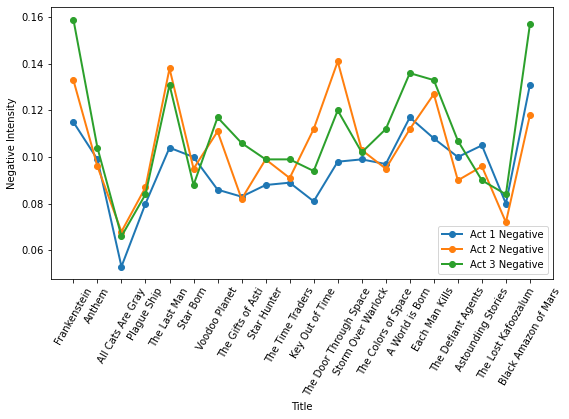

```python
# Negativity across all acts
fig, ax = plt.subplots(figsize=[9, 5])
ax.plot(GutenbergTop20['Title'],GutenbergTop20['Act 1 Negative'], marker='o', linewidth=2, label='Act 1 Negative')
ax.plot(GutenbergTop20['Title'],GutenbergTop20['Act 2 Negative'], marker='o', linewidth=2, label='Act 2 Negative')
ax.plot(GutenbergTop20['Title'],GutenbergTop20['Act 3 Negative'], marker='o', linewidth=2, label='Act 3 Negative')
plt.xticks(rotation=60)
ax.set_xlabel('Title')
ax.set_ylabel('Negative Intensity')
plt.legend()
plt.show()
```

As we can observe, most of the negative instances happen during the second and third acts.

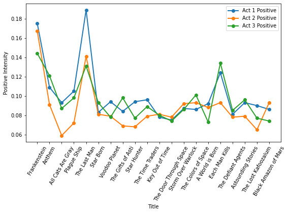

```python
# Positivity across all acts
fig, ax = plt.subplots(figsize=[9, 5])
ax.plot(GutenbergTop20['Title'],GutenbergTop20['Act 1 Positive'], marker='o', linewidth=2, label='Act 1 Positive')
ax.plot(GutenbergTop20['Title'],GutenbergTop20['Act 2 Positive'], marker='o', linewidth=2, label='Act 2 Positive')
ax.plot(GutenbergTop20['Title'],GutenbergTop20['Act 3 Positive'], marker='o', linewidth=2, label='Act 3 Positive')
plt.xticks(rotation=60)
ax.set_xlabel('Title')
ax.set_ylabel('Positive Intensity')
plt.legend()
plt.show()
```

Positivity on the other hand happens the most during the first and third parts.

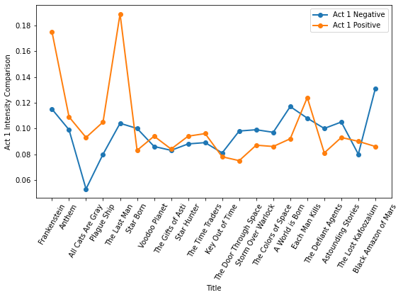

```python
# Act 1 Intensity Comparison
fig, ax = plt.subplots(figsize=[9, 5])
ax.plot(GutenbergTop20['Title'],GutenbergTop20['Act 1 Negative'], marker='o', linewidth=2, label='Act 1 Negative')
ax.plot(GutenbergTop20['Title'],GutenbergTop20['Act 1 Positive'], marker='o', linewidth=2, label='Act 1 Positive')
plt.xticks(rotation=60)
ax.set_xlabel('Title')
ax.set_ylabel('Act 1 Intensity Comparison')
plt.legend()
plt.show()
```

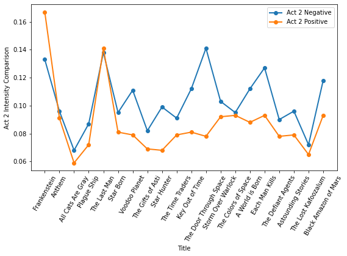

```python
# Act 2 Intensity Comparison
fig, ax = plt.subplots(figsize=[9, 5])
ax.plot(GutenbergTop20['Title'],GutenbergTop20['Act 2 Negative'], marker='o', linewidth=2, label='Act 2 Negative')
ax.plot(GutenbergTop20['Title'],GutenbergTop20['Act 2 Positive'], marker='o', linewidth=2, label='Act 2 Positive')
plt.xticks(rotation=60)
ax.set_xlabel('Title')
ax.set_ylabel('Act 2 Intensity Comparison')
plt.legend()
plt.show()
```

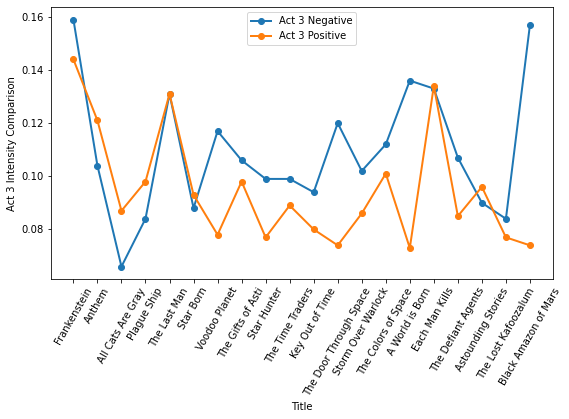

```python
# Act 3 Intensity Comparison
fig, ax = plt.subplots(figsize=[9, 5])
ax.plot(GutenbergTop20['Title'],GutenbergTop20['Act 3 Negative'], marker='o', linewidth=2, label='Act 3 Negative')
ax.plot(GutenbergTop20['Title'],GutenbergTop20['Act 3 Positive'], marker='o', linewidth=2, label='Act 3 Positive')
plt.xticks(rotation=60)
ax.set_xlabel('Title')
ax.set_ylabel('Act 3 Intensity Comparison')
plt.legend()
plt.show()
```

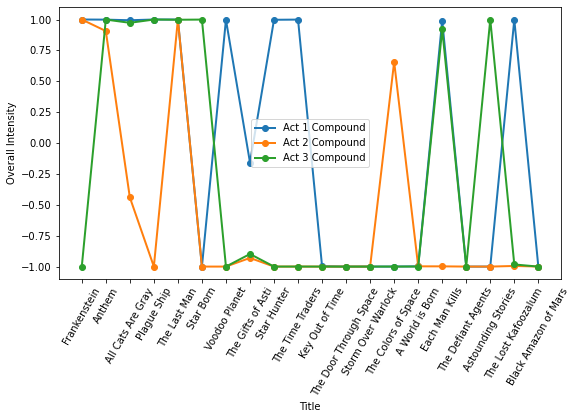

```python
# All acts sentiment compound
fig, ax = plt.subplots(figsize=[9, 5])
ax.plot(GutenbergTop20['Title'],GutenbergTop20['Act 1 Compound'], marker='o', linewidth=2, label='Act 1 Compound')
ax.plot(GutenbergTop20['Title'],GutenbergTop20['Act 2 Compound'], marker='o', linewidth=2, label='Act 2 Compound')
ax.plot(GutenbergTop20['Title'],GutenbergTop20['Act 3 Compound'], marker='o', linewidth=2, label='Act 3 Compound')
plt.xticks(rotation=60)
ax.set_xlabel('Title')
ax.set_ylabel('Overall Intensity')
plt.legend()
plt.show()
```

These compound values support the previous claims as most negative values are both at Act 2 and 3, while positive values are at Acts 1 and 3

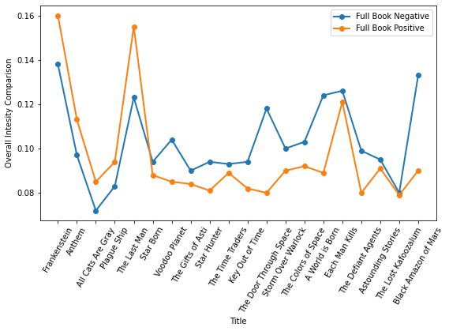

```python
# Overall intensity for each book
fig, ax = plt.subplots(figsize=[9, 5])
ax.plot(GutenbergTop20['Title'],GutenbergTop20['Full Book Negative'], marker='o', linewidth=2, label='Full Book Negative')
ax.plot(GutenbergTop20['Title'],GutenbergTop20['Full Book Positive'], marker='o', linewidth=2, label='Full Book Positive')
plt.xticks(rotation=60)
ax.set_xlabel('Title')
ax.set_ylabel('Overall Intesity Comparison')
plt.legend()
plt.show()
```

Getting the entire negative and positive analysis of each book, we can see that the first five books have an overpowering positivity.

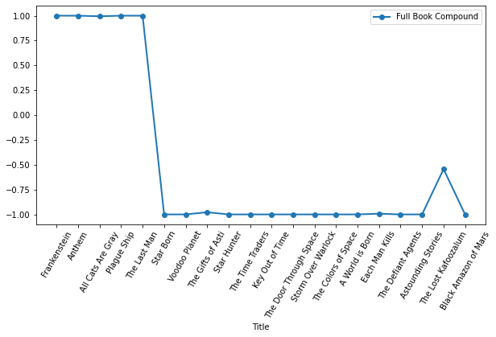

```python
# Full Book Compound values
fig, ax = plt.subplots(figsize=[10, 5])
ax.plot(GutenbergTop20['Title'],GutenbergTop20['Full Book Compound'], marker='o', linewidth=2, label='Full Book Compound')
plt.xticks(rotation=60)
ax.set_xlabel('Title')
plt.legend()
plt.show()
```

## Descriptive Analytics

The following questions were asked earlier.

1. What parts of these books hold the most significant sentiment? Does it follow the traditional three-act structure?
2. How do the endings affect their rankings? Does a bad ending mean a lower ranking? How does the full book analysis compare to this?
3. Which book has the largest negative factor? Why do you think so? Which book has the largest positive factor? Why do you think so?
1. What parts of these books hold the most significant sentiment? Does it follow the traditional three-act structure?

The traditional three-act structure in fiction tackles a story in three parts. Mostly, people refer to it as the beginning, middle, and the end. The three act structure allows readers to ease into the story as it gradually takes the story from the bottom up. Introducing the characters, creating the conflict, and finally facing it [4].

The beginning, or the exposition, sets the stage. It introduces the characters, their lives, their motives and purpose, their "call to adventure". Usually, this part doesn't involve much conflict as the story is still building up.

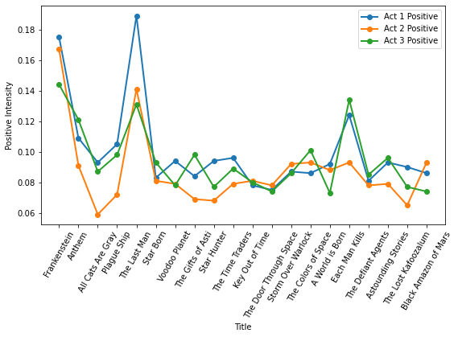

```python
# Positivity across all acts
fig, ax = plt.subplots(figsize=[9, 5])
ax.plot(GutenbergTop20['Title'],GutenbergTop20['Act 1 Positive'], marker='o', linewidth=2, label='Act 1 Positive')
ax.plot(GutenbergTop20['Title'],GutenbergTop20['Act 2 Positive'], marker='o', linewidth=2, label='Act 2 Positive')
ax.plot(GutenbergTop20['Title'],GutenbergTop20['Act 3 Positive'], marker='o', linewidth=2, label='Act 3 Positive')
plt.xticks(rotation=60)
ax.set_xlabel('Title')
ax.set_ylabel('Positive Intensity')
plt.legend()
plt.show()
```

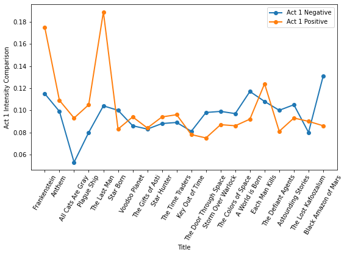

```python
# Act 1 Intensity Comparison
fig, ax = plt.subplots(figsize=[9, 5])
ax.plot(GutenbergTop20['Title'],GutenbergTop20['Act 1 Negative'], marker='o', linewidth=2, label='Act 1 Negative')
ax.plot(GutenbergTop20['Title'],GutenbergTop20['Act 1 Positive'], marker='o', linewidth=2, label='Act 1 Positive')
plt.xticks(rotation=60)
ax.set_xlabel('Title')
ax.set_ylabel('Act 1 Intensity Comparison')
plt.legend()
plt.show()
```

Looking within the beginning of each book, the majority of these books hold a rather positive tone. Although as sci-fi tends to get dark very quick, this part of the book still manages to uphold it's purpose to introduce and set the scene.

Act 2, or the middle, depends more on the direction of the story. In contrast from Act 1, the second act drives it forward. It pushes the characters to face their challenges, and they are, more often than not, forced to go on a journey to find their purpose.

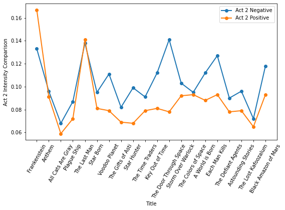

```python
# Act 2 Intensity Comparison
fig, ax = plt.subplots(figsize=[9, 5])
ax.plot(GutenbergTop20['Title'],GutenbergTop20['Act 2 Negative'], marker='o', linewidth=2, label='Act 2 Negative')
ax.plot(GutenbergTop20['Title'],GutenbergTop20['Act 2 Positive'], marker='o', linewidth=2, label='Act 2 Positive')
plt.xticks(rotation=60)
ax.set_xlabel('Title')
ax.set_ylabel('Act 2 Intensity Comparison')
plt.legend()
plt.show()
```

The middle act varies on sentiment, however since sci-fi usually tackles dark themes, most of the sentiment gathered from the books leaned more onto the negative side. Only two books had a higher sentiment in positivity, that being Frankenstein and The Last Man, both written by Mary Shelley.

Act 3, or the resolution, consists of the confrontation and the climax. It is where the highlight of the story takes place. It's where events take a turn, where people discover secrets, where people die, or where people live to tell the tale.

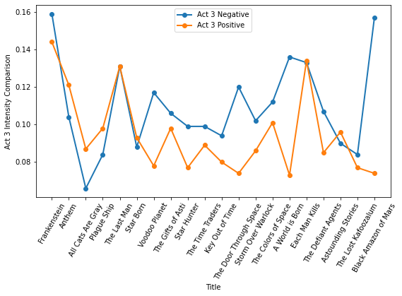

```python
# Act 3 Intensity Comparison
fig, ax = plt.subplots(figsize=[9, 5])
ax.plot(GutenbergTop20['Title'],GutenbergTop20['Act 3 Negative'], marker='o', linewidth=2, label='Act 3 Negative')
ax.plot(GutenbergTop20['Title'],GutenbergTop20['Act 3 Positive'], marker='o', linewidth=2, label='Act 3 Positive')
plt.xticks(rotation=60)
ax.set_xlabel('Title')
ax.set_ylabel('Act 3 Intensity Comparison')
plt.legend()
plt.show()
```

Unlike the second act that only had two stories that had positive undertones, the third act had more of a potential to lean into the positive side.

Comparing all three acts, we can see that most of the story's positivity stems from the first and third act, whilst the negativity stems from the second and third act. This follows the three-act-structure when we base it upon the sci-fi genre. It introduces the characters mildly and amps up the story when it comes to the middle, and finally, it ends the story in one of two ways.

1. How do the endings affect their rankings? Does a bad ending mean a lower ranking? How does the full book analysis compare to this?

Endings are always a hit or miss. It somewhat constitutes a reader's choice for continuing the story. It is critical to the point that most book recommendations stem from endings alone.

Since we are in the digital age, most book reviews are done online. And according to a study in the effect of word of mouth on sales, it was found that customers read review text rather than relying only on summary statistics alone [5].

With the third act having most of the positive endings take up the first few books in the list, we can conclude that the positive endings of these stories made them take the top spots. This claim can further be supported by taking the compound values for each book.

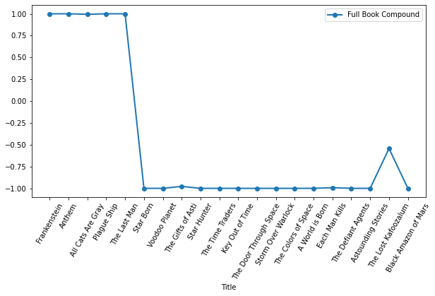

```python
# Full book compound values
fig, ax = plt.subplots(figsize=[10, 5])
ax.plot(GutenbergTop20['Title'],GutenbergTop20['Full Book Compound'], marker='o', linewidth=2, label='Full Book Compound')
plt.xticks(rotation=60)
ax.set_xlabel('Title')
plt.legend()
plt.show()
```

We can see that the first five books are overwhelmingly positive in nature. However, having a bad ending doesn't necessarily mean a low ranking. Take for example the top story of Frankenstein, it had a bad ending, however it took the first spot.

1. Which book has the largest negative factor? Why do you think so? Which book has the largest positive factor? Why do you think so?

This question allows us to determine what book has the highest "positive" or "negative" outcome. Identifying the book and looking at it's summary may help us assume and determine what made it "positive" or "negative"

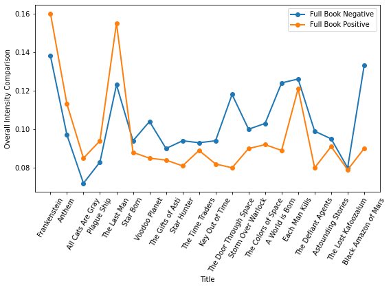

```python
# Overall intensity for each book
fig, ax = plt.subplots(figsize=[9, 5])
ax.plot(GutenbergTop20['Title'],GutenbergTop20['Full Book Negative'], marker='o', linewidth=2, label='Full Book Negative')
ax.plot(GutenbergTop20['Title'],GutenbergTop20['Full Book Positive'], marker='o', linewidth=2, label='Full Book Positive')
plt.xticks(rotation=60)
ax.set_xlabel('Title')
ax.set_ylabel('Overall Intensity Comparison')
plt.legend()
plt.show()
```

Frankenstein by Mary Shelley had both the largest positive and negative factor at 0.160 and 0.138 respectively. This is because it doesn't only tackle the concept of creation in fear, but it also tackles the very framework of morality and ethics.

Even now, after 200 years, Frankenstein, or the Modern Prometheus, is still relevant. Articles are still being written about it as it acts as a cautionary tale. With science at the forefront, this tale of advancement speaks caution into the years to come [6]. Creating both a positive view on the ecstasy of creation, yet giving readers the negative consequences of breathing such creations to life.

## Suggestions

Since this list only focuses on women authors, another data set specifically of male authors can also be used. With this data set, comparisons can be done to see if there is a correlation between gender and the possible use of sci-fi. Do women authors tend to focus more on ethics and morality (soft sci-fi)? Do male authors tend to tackle more into technicality (hard sci-fi)? Is there a correlation at all?

Apart from analyzing the sentiment of each book and comparing them, it would also be nice to analyze the words used within the books to see if it really reflects a "sci-fi" atmosphere. It would really help in understanding why these books resulted in a much more positive or negative sentiment. Do these words hold a connotation that critiques human society?

What if the books were non sci-fi? If the books were the top 20 romance novels, or top 20 fantasy novels, would there be a difference in the positive or negative outcome of the sentiment analysis? Would there be any difference in how these books tackled endings? Would the act-structure be challenged, especially in high-fantasy books?

Questions regarding the author's writing style and how it can correlate to their position in the rating could also be delved into. An analysis on how they carry their words would help in understanding what made them different. Do their sentences carry an urgency to the story? Are their writing styles accessible to readers of any reading grade?

Answering these questions might need a whole different approach, however, one can easily access a system that can classify different writing styles in a document that may help in identifying the unique structure and appeal of a novel. The following system created by Hassaan Elahi & Haris Muneer can be of use if ever these questions may interest you. https://github.com/Hassaan-Elahi/Writing-Styles-Classification-Using-Stylometric-Analysis

## Bibliography

[1] https://literaryterms.net/science-fiction/

[2] https://codereview.stackexchange.com/questions/214857/split-a-number-into-equal-parts-given-the-number-of-parts

[3] https://pythonguides.com/python-plot-multiple-lines/

[4] https://blog.reedsy.com/guide/story-structure/three-act-structure/

[5] Chevalier, J. A., & Mayzlin, D. (2006). The Effect of Word of Mouth on Sales: Online Book Reviews. Journal of Marketing Research, 43(3), 345–354. https://doi.org/10.1509/jmkr.43.3.345

[6] https://stanmed.stanford.edu/why-issues-raised-in-frankenstein-still-matter-200-years-later/#:~:text=A%20framework%20for%20examining%20morality,of%20the%20experiment%20and%20experimenter.

[7] https://realpython.com/python-enumerate/